# Créditos Acuicultura.

## Leyendo Base de Datos.

```r
datos <- read.csv(file = "Cadena_Productiva_Acuicultura_-_Cr_ditos.csv", encoding = "UTF-8")
```

Esta base de datos contiene la información de los créditos solicitados para la cade productiva Acuicola en Colombia, entre Enero de 2004 hasta Junio de 2017. Entre la información disponible se puede encontrar el departamento, municipio, tipo de productor, entre otras mas. La base de datos fue consultada en Octubre de 2017, y se encuentra disponible en el siguiente link: https://www.datos.gov.co/Agricultura-y-Desarrollo-Rural/Cadena-Productiva-Acuicultura-Cr-ditos/6ssc-wybc

Se eliminan las columnas que no serán utilizadas.

```r
datos1 <- datos[ ,-c(8,9,10,18)]

summary(datos1)
```

```
##       Anio           Mes            ClaseCredito       FuenteColocacion
##  Min.   :2004   Min.   : 1.000   Ordinario:18544   Agropecuaria:  702
##  1st Qu.:2010   1st Qu.: 4.000                     Redescuento :17647
##  Median :2013   Median : 7.000                     Sustituta   :  195
##  Mean   :2012   Mean   : 6.728
##  3rd Qu.:2015   3rd Qu.:10.000
##  Max.   :2017   Max.   :12.000
##
##         TipoOperacion                                    Intermediario
##  Nuevo         : 3428   BANCO AGRARIO DE COLOMBIA S A BANAGRARIO:17943
##  Refinanciación:15116   BANCOLOMBIA S.A.                        :  221
##                         BBVA                                    :  169
##                         BANCO BOGOTA                            :   62
##                         ULTRAHUILCA COOPERATIVA                 :   25
##                         MEGABANCO                               :   17
##                         (Other)                                 :  107
##                                TipoProductor
##  Agremiaciones de Pequeños productores:   24
##  Agremiaciones medianos y grandes     :    7
##  Grandes Productores                  :   67
##  Medianos Productores                 :  984
##  Otros Productores                    :   19
##  Pequeños Productores                 :17443
##
##                                    Departamento
##  NARIÑO                                  :4928
##  CAUCA                                   :3271
##  ANTIOQUIA                               :1412
##  CHOCO                                   :1256
##  HUILA                                   : 858
##  VALLE                                   : 852
##  (Other)                                 :5967
##                                     Municipio
##  GUAPI                                   : 1955
##  EL CHARCO                               : 1325
##  SANTA BARBARA                           : 1245
##  MOSQUERA                                :  781
##  TIMBIQUÍ                                :  777
##  BUENAVENTURA                            :  601
##  (Other)                                 :11860
```

[output cut: 9 more lines]

```
##  Asociativo :   25   Créditos garantizados FAG   :17365
##  Empresarial: 2200   Créditos no garantizados FAG: 1179
##  Ordinario  :16319
##
##
##
##
##      valor
##  Min.   :5.000e+05
##  1st Qu.:5.300e+06
##  Median :7.721e+06
##  Mean   :1.358e+07
##  3rd Qu.:1.000e+07
##  Max.   :7.527e+09
##
```

```r
str(datos1)
```

```
## 'data.frame':    18544 obs. of  14 variables:
##  $ Anio            : int  2015 2004 2004 2004 2004 2004 2004 2004 2004 2004 ...
##  $ Mes             : int  12 1 1 1 1 1 1 1 1 1 ...
##  $ ClaseCredito    : Factor w/ 1 level "Ordinario": 1 1 1 1 1 1 1 1 1 1 ...
##  $ FuenteColocacion: Factor w/ 3 levels "Agropecuaria",..: 2 2 2 2 2 2 2 2 2 2 ...
##  $ TipoOperacion   : Factor w/ 2 levels "Nuevo","Refinanciación": 2 2 2 2 2 2 2 2 2 2 ...
##  $ Intermediario   : Factor w/ 24 levels "BANCAFE                                 ",..: 24 2 2 2 2 2 8 2 2 2 ...
##  $ TipoProductor   : Factor w/ 6 levels "Agremiaciones de Pequeños productores",..: 6 4 4 6 6 6 4 6 6 6 ...
##  $ Departamento    : Factor w/ 33 levels "AMAZONAS                                ",..: 19 28 28 30 30 30 31 31 24 8 ...
##  $ Municipio       : Factor w/ 623 levels "ABEJORRAL                               ",..: 553 63 113 218 218 218 72 169 311 54 ...
##  $ Producto        : Factor w/ 3 levels "Acuicultura",..: 1 1 1 1 1 1 2 1 1 1 ...
##  $ Genero          : Factor w/ 3 levels "Hombre","Mujer",..: 1 1 1 2 2 2 1 2 3 1 ...
##  $ TipoCredito     : Factor w/ 3 levels "Asociativo","Empresarial",..: 3 3 3 3 3 3 3 3 2 3 ...
##  $ FAG             : Factor w/ 2 levels "Créditos garantizados FAG",..: 2 2 2 1 1 1 1 2 1 1 ...
##  $ valor           : num  10000000 5000000 5500000 1467000 4900000 ...
```

Paquetes utilizados.

```r
library(dplyr)
library(tidyr)
library(ggplot2)
library(ggthemes)
library(DT)
library(pander)
```

Se transforman las variables o columnas **Año (Anio)** y **mes** a Factor.

```r
datos1 <- datos1 %>%
        mutate(Anio = factor(Anio),
               Mes = factor(Mes))

summary(datos1[ ,c(1,2)])
```

```
##       Anio           Mes
##  2015   :2956   4      :1960
##  2014   :2486   11     :1840
##  2016   :2418   6      :1796
##  2013   :2260   7      :1596
##  2012   :1479   10     :1595
##  2005   :1133   5      :1590
##  (Other):5812   (Other):8167
```

```r
str(datos1[ ,c(1,2)])
```

```
## 'data.frame':    18544 obs. of  2 variables:
##  $ Anio: Factor w/ 14 levels "2004","2005",..: 12 1 1 1 1 1 1 1 1 1 ...
##  $ Mes : Factor w/ 12 levels "1","2","3","4",..: 12 1 1 1 1 1 1 1 1 1 ...
```

## Valor Créditos.

### Cantidad y Valor de los Créditos año a año.

```r
n_cred <- datos1 %>%
        group_by(Anio) %>%
        count() %>%
        ungroup()

n_cred2 <- datos1 %>%
        group_by(Anio) %>%
        summarise(Total = sum(valor)) %>%
        ungroup() %>%
        select(-Anio)

total <- cbind(n_cred, n_cred2)

names(total) <- c("Año", "N", "Total")

datatable(total, class = "cell-border stripe") %>%
        formatStyle(columns = c(1,2), "text-align" = "right") %>%
        formatCurrency(columns = 3, currency = "$", interval = 3,
                       mark = ".", digits = 0)
```

|  | Año | N | Total |
| --- | --- | --- | --- |
| 1 | 2004 | 472 | 5170425400 |
| 2 | 2005 | 1133 | 16302606242 |
| 3 | 2006 | 655 | 18716084047 |
| 4 | 2007 | 745 | 11076528200 |
| 5 | 2008 | 506 | 20353979944 |
| 6 | 2009 | 726 | 19753517568 |
| 7 | 2010 | 750 | 8711021600 |
| 8 | 2011 | 963 | 12519324043 |
| 9 | 2012 | 1479 | 19890111452 |
| 10 | 2013 | 2260 | 23724823856 |

[output cut: 4 more lines]

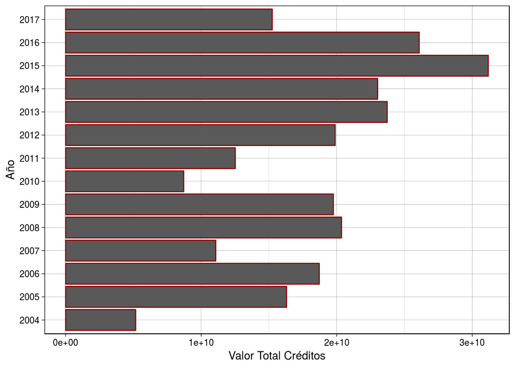

```r
ggplot(data = total, aes(x = as.factor(Año), y = Total)) +
        geom_bar(stat = "identity", color = "darkred") +
        scale_fill_manual(values = "green32") +
        coord_flip() +
        labs(x = "Año", y = "Valor Total Créditos") +
        theme_linedraw()
```

**Nota:** Los valores del año **2017** corresponden unicamente al periodo Enero - Junio.

### Cantidad y Valor Créditos mes a mes.

```r
cred_mes <- datos1 %>%
        group_by(Mes) %>%
        count() %>%
        ungroup()

cred_mes2 <- datos1 %>%
        group_by(Mes) %>%
        summarise(Total = sum(valor)) %>%
        ungroup() %>%
        select(-Mes)

total2 <- cbind(cred_mes, cred_mes2)

datatable(total2, class = "cell-border stripe") %>%
        formatStyle(columns = c(1,2), "text-align" = "right") %>%
        formatCurrency(columns = 3, currency = "$", interval = 3,
                       mark = ".", digits = 0)
```

|  | Mes | n | Total |
| --- | --- | --- | --- |
| 1 | 1 | 987 | 22381783370 |
| 2 | 2 | 1163 | 14169930911 |
| 3 | 3 | 1579 | 15503108619 |
| 4 | 4 | 1960 | 21469121587 |
| 5 | 5 | 1590 | 19478169809 |
| 6 | 6 | 1796 | 25480268383 |
| 7 | 7 | 1596 | 23933347507 |
| 8 | 8 | 1483 | 19588641582 |
| 9 | 9 | 1510 | 15736264020 |
| 10 | 10 | 1595 | 17676352701 |

[output cut: 2 more lines]

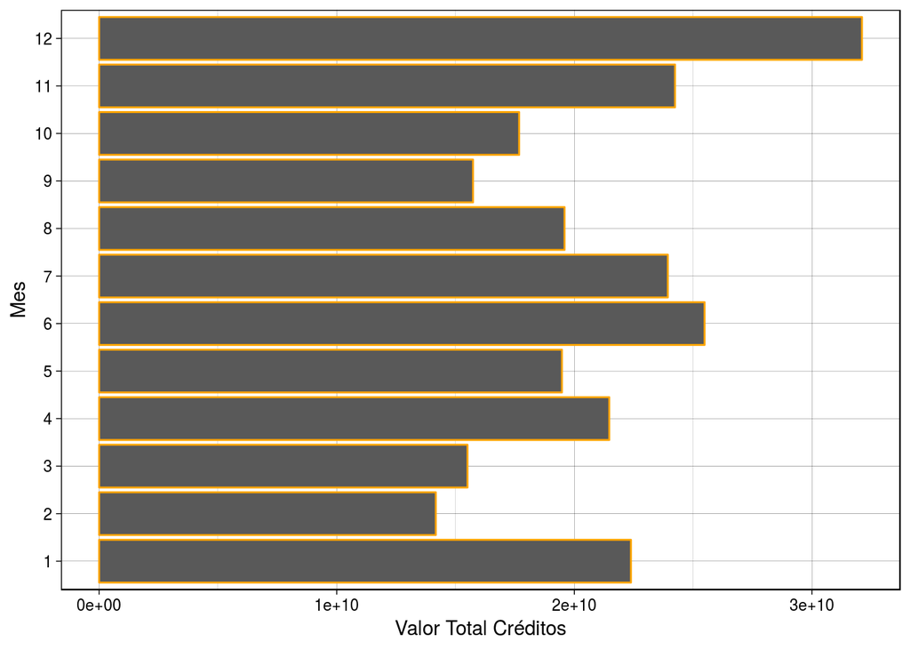

```r
ggplot(data = total2, aes(x = as.factor(Mes), y = Total)) +
        geom_bar(stat = "identity", color = "Orange") +
        scale_fill_manual(values = "green42") +
        coord_flip() +
        labs(x = "Mes", y = "Valor Total Créditos") +
        theme_linedraw()
```

### Fuente de Colocación y Tipo de Operación.

```r
colocacion <- datos1 %>%
        group_by(FuenteColocacion, TipoOperacion) %>%
        count() %>%
        ungroup()

colocacion2 <- datos1 %>%
        group_by(FuenteColocacion, TipoOperacion) %>%
        summarise(Total = sum(valor)) %>%
        ungroup() %>%
        select(-c(FuenteColocacion, TipoOperacion))

colocacionfinal <- cbind(colocacion, colocacion2)

datatable(colocacionfinal) %>%
        formatCurrency(columns = 4, currency = "$", interval = 3,
                       mark = ".", digits = 0)
```

|  | FuenteColocacion | TipoOperacion | n | Total |
| --- | --- | --- | --- | --- |
| 1 | Agropecuaria | Nuevo | 15 | 19762454220 |
| 2 | Agropecuaria | Refinanciación | 687 | 7264773550 |
| 3 | Redescuento | Nuevo | 3376 | 37460917425 |
| 4 | Redescuento | Refinanciación | 14271 | 155104345940 |
| 5 | Sustituta | Nuevo | 37 | 3875007000 |
| 6 | Sustituta | Refinanciación | 158 | 28290939301 |

El tipo de colocación hace referencia a la clasificación dada por **FINAGRO** (Fondo para el Financiamiento del Sector Agropecuario) para los créditos del sector agropecuario, se definen como:

**Redescuento:** Recursos que FINAGRO presta a intermediarios financieros.

**Sustituta:** Recursos propios de los intermediarios financieros que sustituyen la inversión de FINAGRO.

**Agropecuaria:** Recursos propios también de los intermediarios pero que no sustituyen inversión.

Mas información: http://repository.cesa.edu.co/bitstream/handle/10726/1580/MFC_00508.pdf?sequence=1

https://www.finagro.com.co/

### Intermediarios que entregan los créditos.

```r
interm <- datos1 %>%
        group_by(Intermediario) %>%
        count() %>%
        mutate(Total = 18544,
               Porcentaje = n/Total * 100) %>%
        arrange(-Porcentaje)

datatable(interm) %>%
        formatCurrency(columns = 4, currency = "%", digits = 3, before = FALSE)
```

|  | Intermediario | n | Total | Porcentaje |
| --- | --- | --- | --- | --- |
| 1 | BANCO AGRARIO DE COLOMBIA S A BANAGRARIO | 17943 | 18544 | 96.7590595340811 |
| 2 | BANCOLOMBIA S.A. | 221 | 18544 | 1.19176013805004 |
| 3 | BBVA | 169 | 18544 | 0.911345987920621 |
| 4 | BANCO BOGOTA | 62 | 18544 | 0.334339948231234 |
| 5 | ULTRAHUILCA COOPERATIVA | 25 | 18544 | 0.13481449525453 |
| 6 | MEGABANCO | 17 | 18544 | 0.0916738567730802 |
| 7 | FINANCIERA COMULTRASAN | 16 | 18544 | 0.0862812769628991 |
| 8 | BANCO DE OCCIDENTE | 14 | 18544 | 0.0754961173425367 |
| 9 | DAVIVIENDA | 13 | 18544 | 0.0701035375323555 |
| 10 | BANCO SANTANDER COLOMBIA S A | 10 | 18544 | 0.0539257981018119 |

[output cut: 14 more lines]

## Tipo de Productor que solicita el crédito.

### Por género.

```r
productor <- datos1 %>%
        group_by(Genero) %>%
        count()

pander(productor)
```

| Genero | n |
| --- | --- |
| Hombre | 11999 |
| Mujer | 3868 |
| Sociedad | 2677 |

### Por tipo de productor.

```r
productor2 <- datos1 %>%
        group_by(TipoProductor) %>%
        count()

pander(productor2)
```

| TipoProductor | n |
| --- | --- |
| Agremiaciones de Pequeños productores | 24 |
| Agremiaciones medianos y grandes | 7 |
| Grandes Productores | 67 |
| Medianos Productores | 984 |
| Otros Productores | 19 |
| Pequeños Productores | 17443 |

### Tipo de productor y Género.

```r
tp_gen <- datos1 %>%
        group_by(Genero, TipoProductor) %>%
        count()

pander(tp_gen)
```

| Genero | TipoProductor | n |
| --- | --- | --- |
| Hombre | Grandes Productores | 2 |
| Hombre | Medianos Productores | 685 |
| Hombre | Otros Productores | 4 |
| Hombre | Pequeños Productores | 11308 |
| Mujer | Medianos Productores | 183 |
| Mujer | Pequeños Productores | 3685 |
| Sociedad | Agremiaciones de Pequeños productores | 24 |
| Sociedad | Agremiaciones medianos y grandes | 7 |
| Sociedad | Grandes Productores | 65 |
| Sociedad | Medianos Productores | 116 |
| Sociedad | Otros Productores | 15 |
| Sociedad | Pequeños Productores | 2450 |

### Valor Créditos solitidos por Pequeños y Medianos Productores.

```r
valor_c <- datos1 %>%
        filter(TipoProductor %in% c("Pequeños Productores",
                                    "Medianos Productores")) %>%
        group_by(Genero, TipoProductor) %>%
        summarise(Total = sum(valor))

names(valor_c) <- c("Género", "Tipo de Productor", "Total en $")

panderOptions("decimal.mark", ",")
panderOptions("big.mark", ".")
panderOptions("digits", 15)
pander(valor_c[1:4, ], style = "rmarkdown")
```

| Género | Tipo de Productor | Total en $ |
| --- | --- | --- |
| Hombre | Medianos Productores | 21.705.902.572 |
| Hombre | Pequeños Productores | 86.900.920.573 |
| Mujer | Medianos Productores | 4.976.702.400 |
| Mujer | Pequeños Productores | 28.075.744.142 |

### Valor Créditos Año a Año de pequeños productores (Hombres y Mujeres).

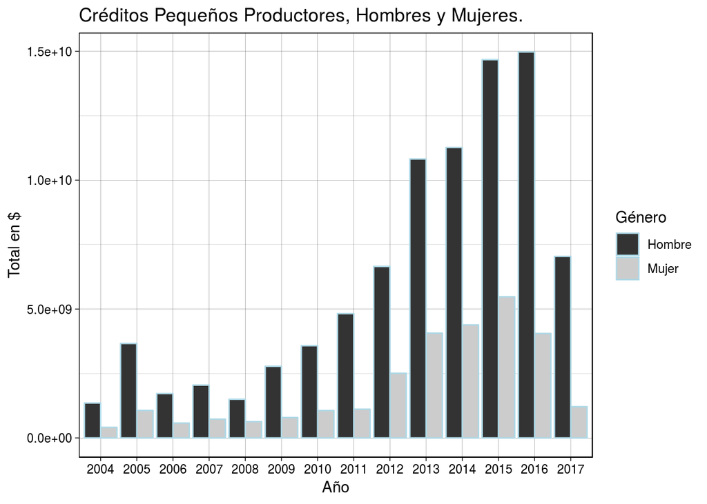

```r
PP_cred <- datos1 %>%
        filter(TipoProductor == "Pequeños Productores" & Genero != "Sociedad") %>%
        group_by(Genero, Anio) %>%
        summarise(Total = sum(valor))

ggplot(data = PP_cred, aes(x = as.factor(Anio), y = Total, group = Genero)) +
        geom_bar(aes(fill = Genero), stat = "identity", position = "dodge", color = "lightblue") +
        labs(x = "Año", y = "Total en $",
             title = "Créditos Pequeños Productores, Hombres y Mujeres.",
             fill = "Género") +
        scale_fill_grey() +
        theme_linedraw()
```

### En que se invierte el crédito??

```r
producto <- datos1 %>%
        group_by(Producto) %>%
        count() %>%
        mutate(Total = 18544,
               Porcentaje = n/Total * 100) %>%
        arrange(-Porcentaje)

panderOptions("round", 3)
pander(producto, style = "rmarkdown")
```

| Producto | n | Total | Porcentaje |
| --- | --- | --- | --- |
| Equipos para actividades pesca y acuicul | 14.279 | 18.544 | 77,001 |
| Acuicultura | 4.256 | 18.544 | 22,951 |
| Sostenimiento acuicultura | 9 | 18.544 | 0,049 |

## Información Créditos por Departamento.

### Cantidad y Valor de los créditos.

```r
departamento <- datos1 %>%
        group_by(Departamento) %>%
        count() %>%
        ungroup()

departamento2 <- datos1 %>%
        group_by(Departamento) %>%
        summarise(Total = sum(valor)) %>%
        ungroup() %>%
        select(-1)

dep_final <- cbind(departamento, departamento2)

datatable(dep_final) %>%
        formatCurrency(columns = 3, currency = "$", interval = 3, mark = ".", digits = 0)
```

|  | Departamento | n | Total |
| --- | --- | --- | --- |
| 1 | AMAZONAS | 18 | 504935000 |
| 2 | ANTIOQUIA | 1412 | 12931510743 |
| 3 | ARAUCA | 123 | 728206000 |
| 4 | ATLANTICO | 116 | 1708013937 |
| 5 | BOGOTA D.E. | 5 | 654720000 |
| 6 | BOLIVAR | 456 | 29758304708 |
| 7 | BOYACA | 150 | 1929358000 |
| 8 | CALDAS | 623 | 4107672980 |
| 9 | CAQUETA | 102 | 524372200 |
| 10 | CASANARE | 308 | 4240199171 |

[output cut: 23 more lines]

### Porcentaje Hombres y Mujeres que solicitaron Créditos en cada Departamento.

```r
porcentaje <- datos1 %>%
        filter(Genero != "Sociedad") %>%
        group_by(Departamento, Genero) %>%
        count() %>%
        ungroup()

porcentaje2 <- porcentaje %>%
        group_by(Departamento) %>%
        mutate(Total = sum(n),
               Porcentaje = round(n/Total *100, digits = 2))

datatable(porcentaje2)
```

|  | Departamento | Genero | n | Total | Porcentaje |
| --- | --- | --- | --- | --- | --- |
| 1 | AMAZONAS | Hombre | 14 | 18 | 77.78 |
| 2 | AMAZONAS | Mujer | 4 | 18 | 22.22 |
| 3 | ANTIOQUIA | Hombre | 1029 | 1271 | 80.96 |
| 4 | ANTIOQUIA | Mujer | 242 | 1271 | 19.04 |
| 5 | ARAUCA | Hombre | 112 | 122 | 91.8 |
| 6 | ARAUCA | Mujer | 10 | 122 | 8.2 |
| 7 | ATLANTICO | Hombre | 81 | 92 | 88.04 |
| 8 | ATLANTICO | Mujer | 11 | 92 | 11.96 |
| 9 | BOGOTA D.E. | Hombre | 3 | 4 | 75 |
| 10 | BOGOTA D.E. | Mujer | 1 | 4 | 25 |

[output cut: 56 more lines]

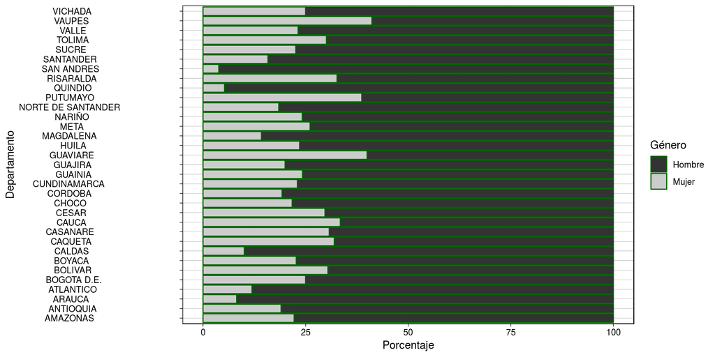

```r
ggplot(data = porcentaje2, aes(x = Departamento, y = Porcentaje, fill = Genero)) +
        geom_bar(stat = "identity", color = "darkgreen") +
        labs(x = "Departamento", y = "Porcentaje", fill = "Género") +
        theme_linedraw() +
        scale_fill_grey() +
        coord_flip()
```